# Application Activity

CO2 Uptake Experiment

Author

Nathan Lunceford

# Background

This example is taken from an experiment listed in the R help files under `?CO2`.

“An experiment on the cold tolerance of the grass species Echinochloa crus-galli was conducted. The CO2 uptake of six plants from Quebec and six plants from Mississippi was measured at several levels of ambient CO2 concentration. Half the plants of each type were chilled overnight before the experiment was conducted.” Plants were considered tolerant to the cold if they were still able to achieve high CO2 uptake values after being chilled.

Ignoring the Plant ID for a moment, there are three factors that possibly effect the `uptake` of a plant. These include `Type`, `Treatment`, and `conc`. The factor `Type` has two levels, **Quebec** and **Mississippi**. The factor `Treatment` has two levels **chilled** and **nonchilled** and the factor `conc` has seven levels 95, 175, 250, 350, 500, 675, and 1000.

Conc is related to the ambient concentration of CO2.

# Summarizing Data

Our main interest in CO2 uptake and how the other factors impact it. We will first do a univariate analysis of uptake.

## Univariate Analysis

Create a table with the overall summary statistics for uptake:

```r
# This is NEW!  if you tell R to knit the favstats output using the "kable" function, it will look a lot nicer when the document is rendered.

uptake_favstat <- favstats(CO2$uptake)

knitr::kable(uptake_favstat)
```

|  | min | Q1 | median | Q3 | max | mean | sd | n | missing |
| --- | --- | --- | --- | --- | --- | --- | --- | --- | --- |
|  | 7.7 | 17.9 | 28.3 | 37.125 | 45.5 | 27.2131 | 10.81441 | 84 | 0 |

Create a histogram of the uptake data:

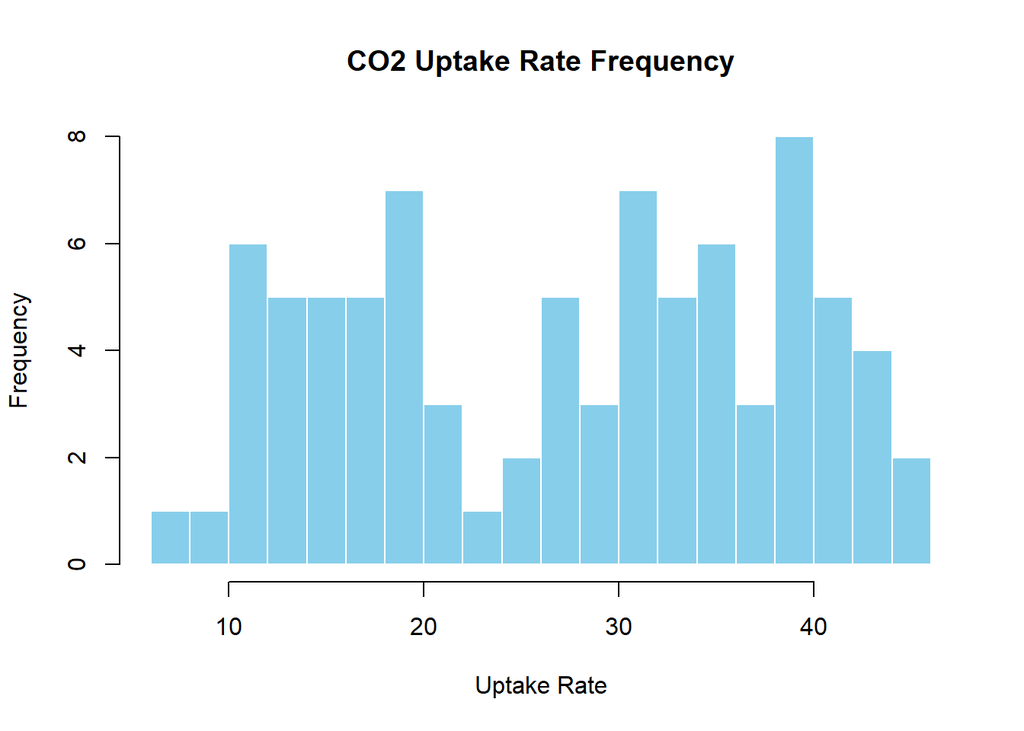

```r
hist(CO2$uptake,
     main = "CO2 Uptake Rate Frequency",
     xlab = "Uptake Rate",
     ylab = "Frequency",
     col = "skyblue",
     border = "white",
     breaks = 20)
```

# What Factors Impact Uptake?

We will now look at how other factors might impact CO2 uptake.

## Impact of Plant Type on Uptake

Create a table of summary statistics of uptake for each type of plants used in the experiment.

```r
# Calculate favorite statistics for the uptake variable grouped by Type
uptake_type_favstat <- favstats(~uptake | Type, data = CO2)

# Print the summary statistics
knitr::kable(uptake_type_favstat)
```

| Type | min | Q1 | median | Q3 | max | mean | sd | n | missing |
| --- | --- | --- | --- | --- | --- | --- | --- | --- | --- |
| Quebec | 9.3 | 30.325 | 37.15 | 40.15 | 45.5 | 33.54286 | 9.673830 | 42 | 0 |
| Mississippi | 7.7 | 13.875 | 19.30 | 28.05 | 35.5 | 20.88333 | 7.815773 | 42 | 0 |

Create a side-by-side boxplot of uptake for each type of plants used in the experiment.

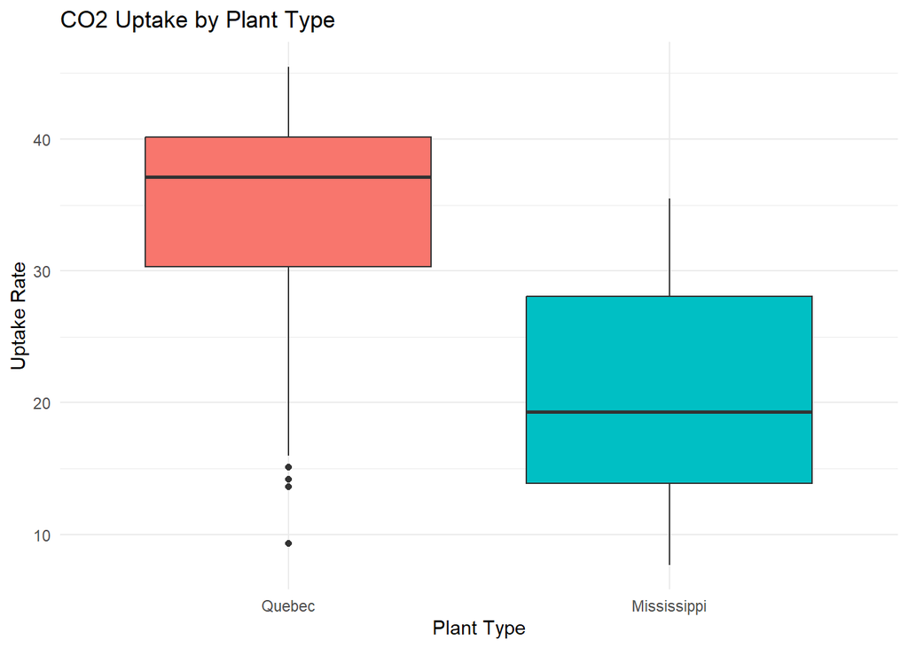

```r
ggplot(data = CO2, aes(x = Type, y = uptake, fill = Type)) +
  geom_boxplot() +
  labs(title = "CO2 Uptake by Plant Type",
       x = "Plant Type",
       y = "Uptake Rate") +
  theme_minimal() +
  theme(legend.position = "none")
```

## Impact of Treatment on Uptake

Create a table of summary statistics of uptake for each treatment used in the experiment.

```r
# Calculate favorite statistics for the uptake variable grouped by treatment
uptake_treatment_favstat <- favstats(~uptake | Treatment, data = CO2)

# Print the summary statistics
knitr::kable(uptake_treatment_favstat)
```

| Treatment | min | Q1 | median | Q3 | max | mean | sd | n | missing |
| --- | --- | --- | --- | --- | --- | --- | --- | --- | --- |
| nonchilled | 10.6 | 26.475 | 31.3 | 38.7 | 45.5 | 30.64286 | 9.704994 | 42 | 0 |
| chilled | 7.7 | 14.525 | 19.7 | 34.9 | 42.4 | 23.78333 | 10.884312 | 42 | 0 |

Create a side-by-side boxplot of uptake for each treatment used in the experiment.

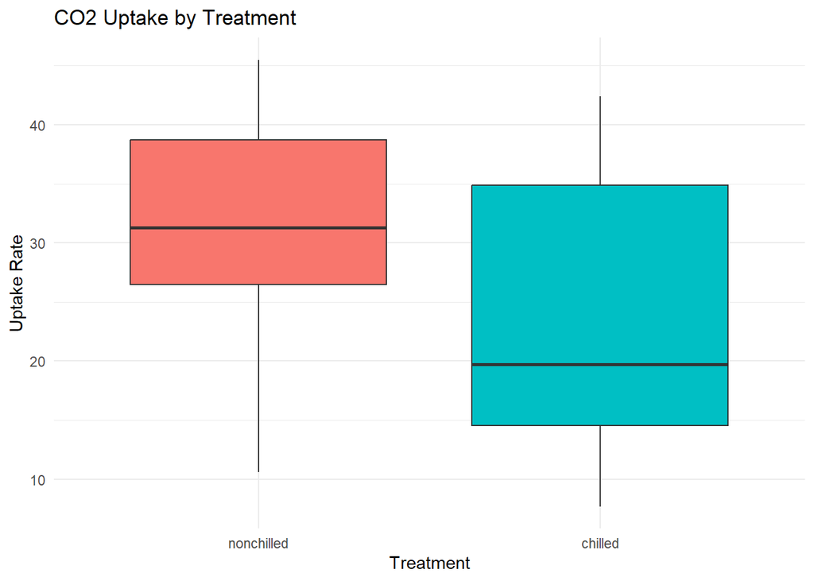

```r
ggplot(data = CO2, aes(x = Treatment, y = uptake, fill = Treatment)) +
  geom_boxplot() +
  labs(title = "CO2 Uptake by Treatment",
       x = "Treatment",
       y = "Uptake Rate") +
  theme_minimal() +
  theme(legend.position = "none")
```

## Impact of Ambient CO2 Concentration on Uptake

Create a table of summary statistics of uptake for each level of CO2 found in the experiment.

```r
# Calculate favorite statistics for uptake for each level of CO2 found in the experiment
uptake_conc_favstat <- favstats(~uptake | conc, data = CO2)

# Print the summary statistics
knitr::kable(uptake_conc_favstat)
```

| conc | min | Q1 | median | Q3 | max | mean | sd | n | missing |
| --- | --- | --- | --- | --- | --- | --- | --- | --- | --- |
| 95 | 7.7 | 10.575 | 11.65 | 14.425 | 16.2 | 12.25833 | 2.735111 | 12 | 0 |
| 175 | 11.4 | 18.900 | 21.50 | 27.300 | 32.4 | 22.28333 | 6.271992 | 12 | 0 |
| 250 | 12.3 | 23.875 | 30.45 | 35.525 | 40.3 | 28.87500 | 8.988895 | 12 | 0 |
| 350 | 13.0 | 25.650 | 32.90 | 37.600 | 42.1 | 30.66667 | 9.596527 | 12 | 0 |
| 500 | 12.5 | 26.250 | 32.45 | 38.675 | 42.9 | 30.87500 | 9.671056 | 12 | 0 |
| 675 | 13.7 | 26.625 | 33.90 | 39.300 | 43.9 | 31.95000 | 9.534960 | 12 | 0 |
| 1000 | 14.4 | 26.325 | 37.10 | 41.650 | 45.5 | 33.58333 | 10.411867 | 12 | 0 |

Create a side-by-side boxplot of uptake for each level of CO2 found used in the experiment.

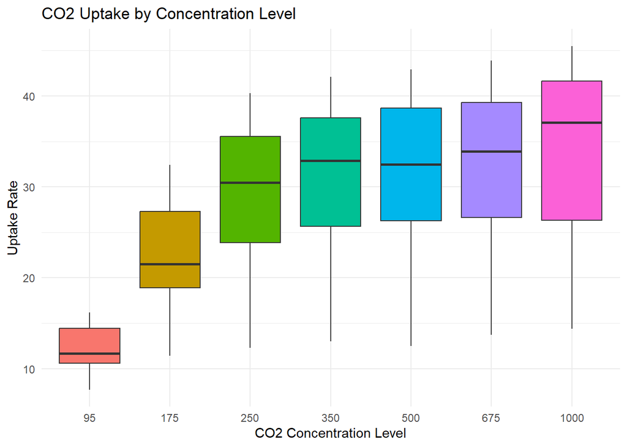

```r
ggplot(data = CO2, aes(x = as.factor(conc), y = uptake, fill = as.factor(conc))) +
  geom_boxplot() +
  labs(title = "CO2 Uptake by Concentration Level",
       x = "CO2 Concentration Level",
       y = "Uptake Rate") +
  theme_minimal() +
  theme(legend.position = "none")
```

# Conclusion

## What makes this an experiment?

The background suggests this study was an experiment. In your own words, describe the difference between an experiment and an observational study.

What would this study have looked like if it had been an observational study?

**An experiment involves manipulation of variables, an observational study involves observing and measuring variables without manipulating them.**  
**To make the experiment an observational study you would have to change the focus from understanding the direct impact of various factors on uptake to observing patterns in how different naturally occurring factors might correlate with uptake in real-world settings.**

## What is the Population of this study?

Describe in your own words what the population of this study could be. How broad can we make our conclusions?

**The population in this experiment are the the type of plants being studied.**

## What are your recommendations?

If you were to recommend a planting scenario to maximize CO2 uptake, what would you recommend based on the summaries provided?

**I would recommend planting the Quebec type, not chilling the plants and having a co2 concentration of about 1000 or higher.**